# Uncertainty Modelling in Mass Cytometry

Eric Barnhill

January 16, 2018

## Introduction

The goal of this experiment was to estimate robustness and uncertainty of effects in a mass cytometry experiment. In this experiment, the response of contrast agents in six cell types was studied. As the cell types behave biologically differently, a separate statistical model was built for each.

In each model, three experiments were run, in which cell samples were subjected to three differing contrast agents:

- Magnevist
- Dotarem
- Gadevist

and a control condition. Cells were subjected to these agents at three differing concentrations: 0.1, 0.3, and 1, and the control condition was considered a concentration of 0.0. Thus a fully specified model for the experiment would be:

$$E(Y_{ijk}) = \beta_{0} + u_{0j} + w_{0k} + (\beta_{1} + u_{1j} + w_{1k})conc_{i} + \epsilon_{i}$$
where $\beta_{0}$ is the global intercept, $u_{0j}$ is a random intercept for experiment, $w_{0k}$ is a random intercept for contrast agent, and similarly, $\beta_{1}$, $u_{1j}$ and $w_{1k}$ are adjustments to the slope of the continuous concentration variable $conc$.

The data were acquired with a mass cytometer which provides several thousand measurements for each category. A summary plot from the mass cytometer for one experiment is below:

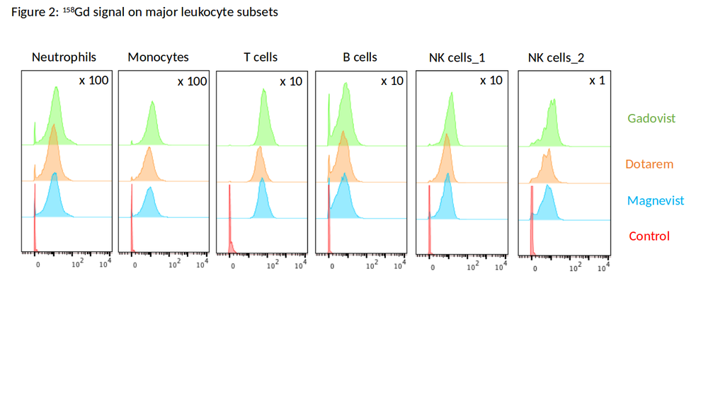

For this experiment we asked the scientific question: Does the cell signal change with contrast agent, for a given concentration?

## Data exploration

Data were cleaned and converted to tall format:

```r
source('masscyto_clean_gather_data.R')
MASSCYTO_DIR = "/home/ericbarnhill/Documents/code/R/2017-12-15-masscyto/"
mass_cyto_xls_path <- file.path(MASSCYTO_DIR, "angela.xlsx")
mass_cyto <- read.xls(xls=mass_cyto_xls_path, header=FALSE, skip=3, nrows=30)[,-(5:10)]
mass_cyto_tall <- clean_gather_data(mass_cyto)
str(mass_cyto_tall)
```

```
## 'data.frame':    900 obs. of  6 variables:
##  $ Experiment     : Factor w/ 3 levels "1","2","3": 1 1 1 1 1 1 1 1 1 1 ...
##  $ ContrastAgent  : Factor w/ 4 levels "control","Dotarem",..: 1 4 4 4 2 2 2 3 3 3 ...
##  $ Concentration  : Factor w/ 4 levels "0","0.1","0.3",..: 1 2 3 4 2 3 4 2 3 4 ...
##  $ value          : num  0.8 1.59 4.85 16.8 2.3 4.97 13.7 2.62 5.4 16 ...
##  $ CellType       : Factor w/ 6 levels "B cells","Monocytes",..: 3 3 3 3 3 3 3 3 3 3 ...
##  $ MeasurementType: Factor w/ 5 levels "CV Gd158","Mean",..: 2 2 2 2 2 2 2 2 2 2 ...
```

Medians for each experimental condition are explored below:

```r
source('masscyto_explore_medians.R')
m <- explore_medians(mass_cyto_tall)
```

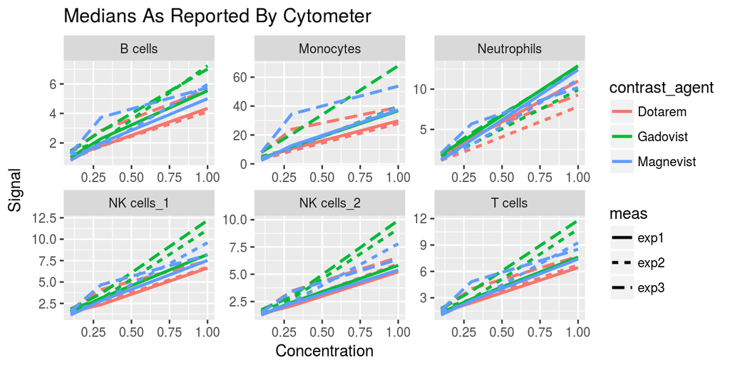

We point out two key properties for modeling this data.

First, there is considerable overlap between results, as the concentration approaches zero, for contrast agents and experiments. Consequently, within each of the six cell types, there is unlikely to be an independent intercept for either contrast agent or experiment. Rather, the variable quantity is the *slope of the lines*, that is, the increase in signal for each unit of concentration. The response of the signal to concentration appears approximately linear and therefore it appears appropriate to model the slope linearly.

Second, the third experiment (longer dashes) overall appeared higher than the other experiments while the first and second experiment values appeared similar. A boxplot confirms that the median is, for each data set, looking higher on the third experiment:

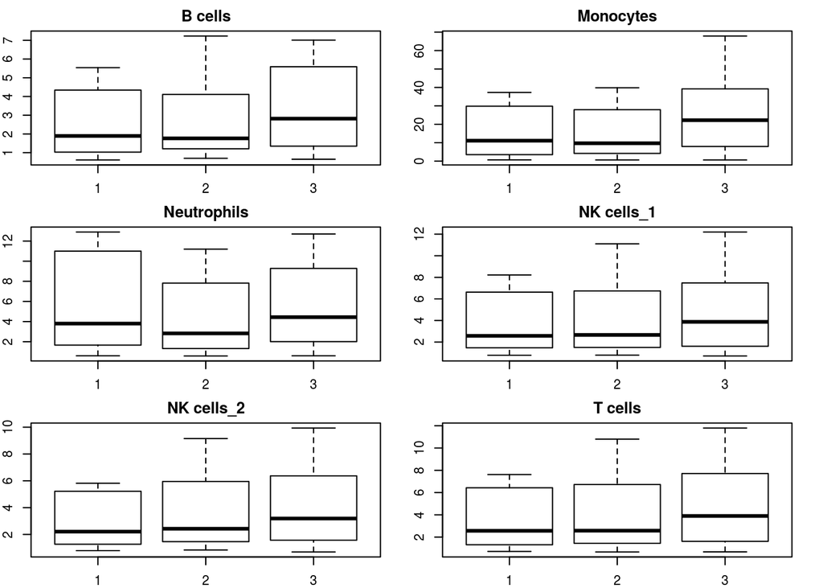

```r
par(mfrow=c(3,2))
par(mar=c(2,2,2,2))
for (n in levels(mass_cyto_tall$CellType)) {
    boxplot(value ~ Experiment, subset(mass_cyto_tall, MeasurementType == "Median" & CellType == n))
    title(n)
    xlab("Experiment")
}
```

Next we move on from medians alone to overall summary statistics, to evaluate the distribution of values:

```r
source('masscyto_quantiles_table.R')
qt <- quantiles_table(mass_cyto_tall)
```

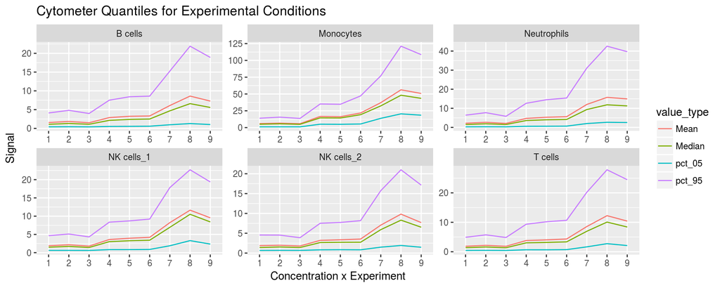

Here we can see that the mean is consistently higher than the median, and the data shows heavy right skew. This suggests that a normal model is inappropriate for the data and a gamma or lognormal model would be more suitable. The principal criterion for deciding between these two models is whether the log of the distribution is normal (lognormal) or has left skew (gamma). Fortunately part of the mass cytometer output is histograms of the distributions as shown in Figure 1. Consequently inspection shows that the distributions have some left skew, and a gamma model was chosen.

## Generation of parameter distributions: Methods

The first step in creating the statistical model was to generate a statistical distribution for each experimental condition that best approximated the four summary statistics of mean, median, 5% and 95%. Two common methods are maximum-likelihood estimation (MLE) and the method of moments (MOM). However, it is well known that in gamma distributions, deviation of the data from the model can cause very different estimates in both of these methods, and there is a uniqueness problem. Consequently distributions were additionally estimated using Approximate Bayesian Computation (ABC). ABC samples repeatedly over the parameter space to generate model-free estimates of the parameters. ABC has the additional benefit that the uncertainty of the fit to a typical gamma distribution is estimated. To sample over a gamma model with the above four summary statistics, the following ABC model was used:

```r
gamma_model <- function(par){
    samples <- rgamma(10000, shape=par[1], rate=par[2])
    mn <- mean(samples)
    mdn <- median(samples)
    qtls <- quantile(samples, c(0.05, 0.95))
    sum_stats <- c(mn, mdn, qtls[1], qtls[2])
    return(sum_stats)
}
```

The inline code then calls the model with a set of parameters:

```r
call_abc_model <- function() {
m2 <- ABC_mcmc(method="Marjoram", model=gamma_model,                             prior=list(c("unif",1e-3,10),c("unif",1e-3,5)),
summary_stat_target=group_sum_stats, n_rec = N_REC,
verbose=TRUE)
}
```

For a point of comparison, we also used an MLE method designed with R’S *optim* function:

```r
est_gamma_mle <- function(group_sum_stats) {
    ofn <- function(x,q) {
        sum(abs(c(
            q[c(3,1,4)]-qgamma(c(0.05,0.5,0.95),x[1],x[2]),
            q[2] - median(rgamma(10000, x[1], x[2]))
        )^2))
    }
    dist <- optim(c(1,1),fn=ofn,q=group_sum_stats)
}
```

Finally for a second comparison, we used MOM. As the median is not a moment, the MOM approach was expected to be a less accurate estimator. Gamma distributions were estimated with the method of moments using an adaptation of the R code found [here](http://www.medicine.mcgill.ca/epidemiology/Joseph/PBelisle/GammaParmsFromQuantiles.html).

## Generation of Parameter Distributions: Results

The Figure below shows the distributions from the experiment (exp) with the predicted distributions of the three methods (ABC, MLE, and MOM).

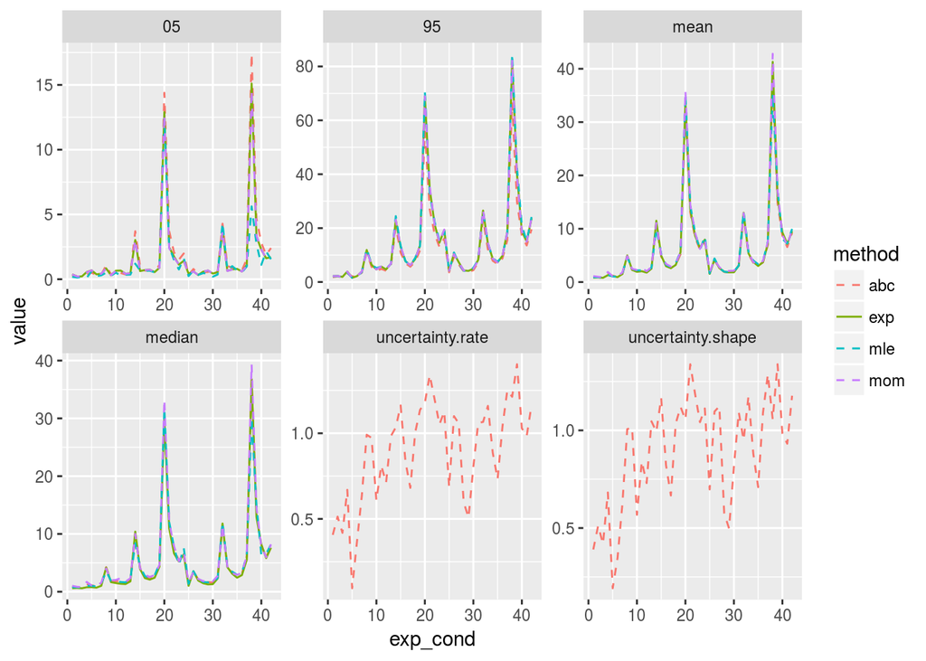

```r
source("masscyto_predict_summary_stats.R")
load("dist_models.Rdata")
results_list <- collect_dist_results(mass_cyto_tall, dist_models)
plot_dist_results(results_list$dist_results)
```

Qualitatively the three methods all approximate the distributions relatively closely. Finally, the fact that the ABC estimation method inherently estiamtes the uncertainty of the distribution fit is exploited to make the final two plots. Here we can see that when normalizing for signal values, the distribution increases in uncertainty, but not dramatically so.

The table below shows the normalized standard deviations, for each estimation method, for each summary statistic:

```r
(make_error_table(results_list$error_results))
```

```
##         stat        abc        mle         mom
## 1     05.err 0.22507222 0.25626959 0.015505662
## 2     95.err 0.13308250 0.03571045 0.008018481
## 3   mean.err 0.04008438 0.06627253 0.100139056
## 4 median.err 0.14577793 0.16952138 0.236052056
```

The results here have some unexpected elements. ABC is the best measure of the mean and median, with MLE second best and MOM worst. However MOM was the best at estimating the more distant quantiles and this was unexpected. It is possible that the ABC did not have enough draws to estimate the tails of the distribution (this is a common problem) and it will be run again with more draws, requiring a few days’ processing time, to verify this. Overall, as the ABC was the best predictor of mean and median, it was used to build the multilevel model; however MLE had quite similar results and would probably work just as well to save time.

## Multilevel Statistical Model: Methods

Models were created for each cell type and run in JAGS. As the distributions were estimated as gamma distributions, it was a straightforward choice to apply a multilevel gamma generalized linear model (GLM) with a log link function. However, for faster initial testing and to get intuitions about the results, the distributions were also modeled as normal.

The plot of medians above shows that the values for all contrast agents converged toward zero as the concentration was decreased. Consequently, it did not appear that it would be appropriate to model different intercepts for contrast agent or experiment. Initial tests showed that these models did not converge, in either gamma or normal forms. A snippet of the fully specified gamma model in JAGS, which did not converge, is presented below: `for (i in 1:n_samps) { value[i] ~ dgamma(shape, shape / pred[i]) log(pred[i]) <- b0[c_typ[i]] + b1[c_typ[i]]*conc[i] + b2[cont_ag[i]] + b3[cont_ag[i]]*conc[i] + b4[exp[i]] }` Rather, the primary statistical effect was in the slope of the concentration variable $conc_{i}$ from the fully specified equation. The slope seemed dependent on experiment but this was accepted as a source of error for the model. Consequently the final model consisted only of a single global intercept, and a random slope by contrast agent. The final gamma model is presented below in JAGS code:

```r
cat(readLines('masscyto_model_celltype_dgamma_2.txt'), sep = '\n')
```

```
model {
    for (i in 1:n_samps) {
        value[i] ~ dgamma(shape, shape / pred[i])
        log(pred[i]) <- b0 + b1[cont_ag[i]]*conc[i]
    }

    b0 ~ dnorm(0, 1/100)

    for (p in 1:n_cont_ags) {
        b1[p] ~ dnorm(mu_cont_ag, tau_cont_ag)
    }

    shape ~ dunif(0.001, 1000)

    mu_cont_ag ~ dnorm(0, 1 / 10000)
    sig_cont_ag ~ dunif(0.001, 1000)
    tau_cont_ag <- 1 / sig_cont_ag^2

}
```

where b0 is the global intercept, and b1[1] to b1[4] are slopes for the four contrast agents of control, Dotarem, Gadovist and Magnevist.

Several diagnostics were used to evaluate the performance of this model. Goodness of fit was measured with the Divergence Information Criterion (DIC), and compared to DIC results for similar models based on normal and lognormal distributions. To ensure convergence of the MCMC chains, the Gelman-Rubin diagnostic and Autocorrelation diagnostics were also checked. The final shape and rate parameters were then used to predictively model the original data and error was measured.

## Multilevel Model: Results

```r
load(file = "final_models.RData")
```

The functions to run the models are found in *masscyto_model_by_cell_type.R*. Trace and density plots for the MCMC chains for a cell type chosen at random are shown below:

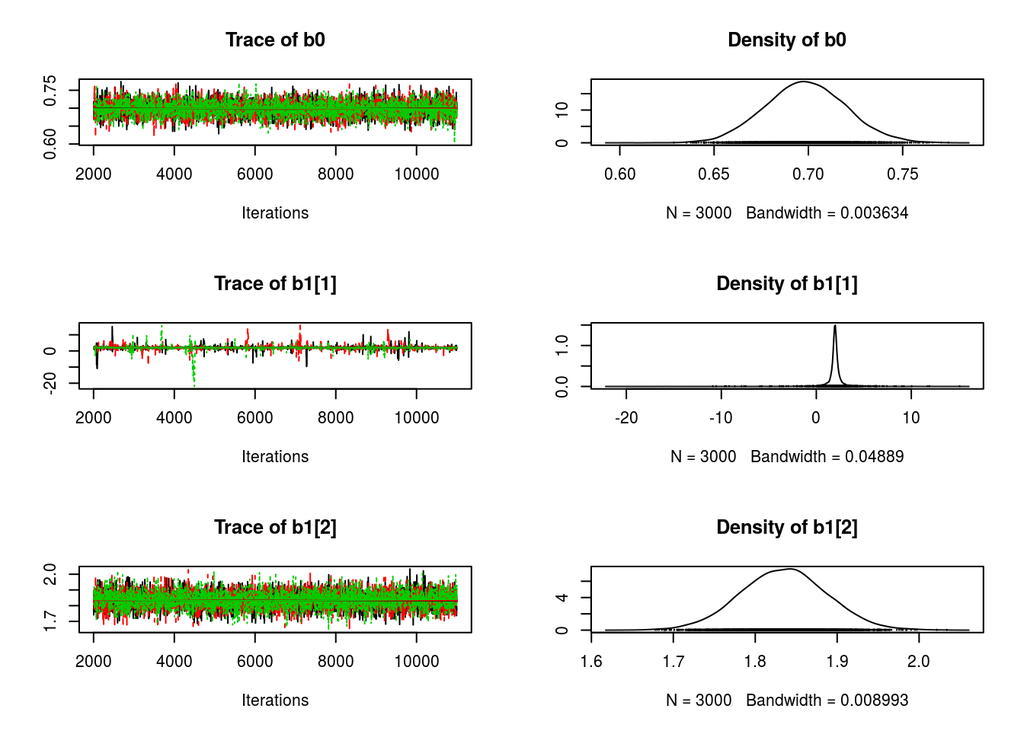

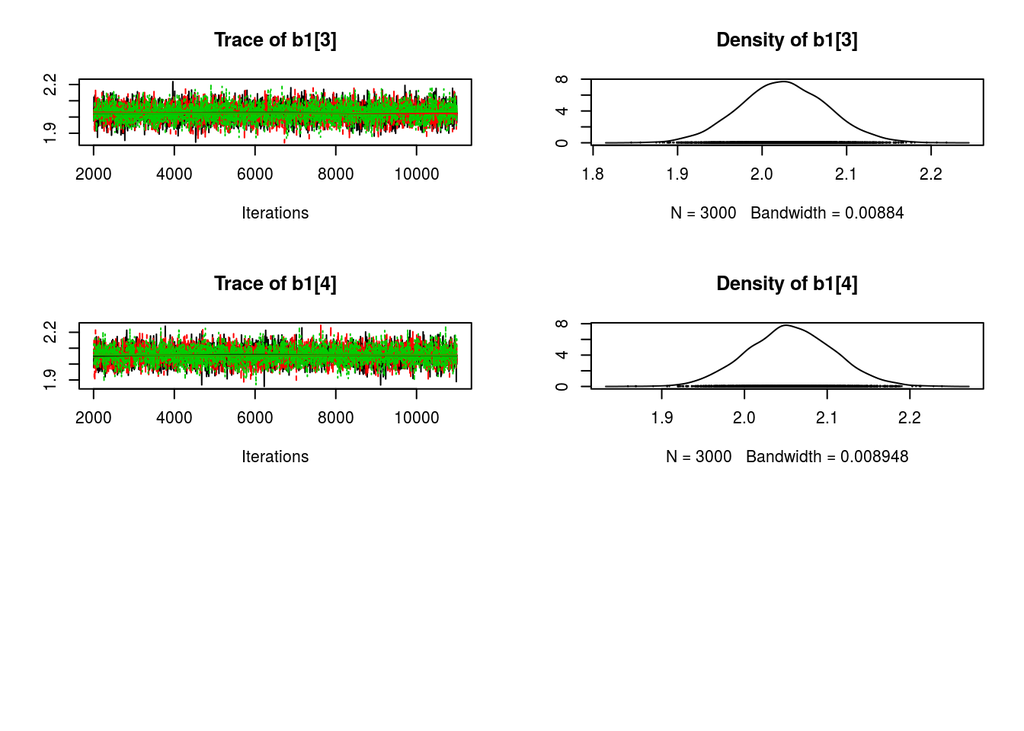

```r
plot(models[[2]][[3]]$sim)
```

The model converged well for all variables except b1[1]. This is expected as this variable is the control condition, which only has concentrations of 0, and therefore a slope across concentrations cannot be estimated. These observations are confirmed with the Gelman-Rubin diagnostic, here chosen for a second cell type:

```r
models[[2]][[1]]$Gelman
```

```
## Potential scale reduction factors:
##
##       Point est. Upper C.I.
## b0          1.00       1.01
## b1[1]       1.04       1.04
## b1[2]       1.00       1.00
## b1[3]       1.00       1.01
## b1[4]       1.00       1.01
##
## Multivariate psrf
##
## 1
```

where only the b1[1] variable, which again is the slope across concentrations for the control condition, did not converge.